# Psychological Profiling using digital footprints

## Exercises and Answers

1. **A study was conducted to test the effect of applied psychological therapy on reducing the negative effects of puberty. For this purpose, three groups of 5 subjects were selected. The first group received family therapy, the second group received individual therapy, and the third group received no help. After six months, levels of depression, anxiety, and social chaos were examined. The following results were obtained (the higher the value the higher the level of the trait): Group 1: (6, 8, 9), (4, 3, 3), (0, 2, 8), (4, 1, 6), (0, 8, 4); Group 2: (11, 9, 8), (11, 6, 6), (5, 7, 4), (8, 6, 5), (4, 9, 4); Group 3: (12, 11, 6), (8, 8, 5), (9, 6, 7), (8, 10, 8), (11, 4, 3). Construct a Naive Bayesian model (with normal distributions). What is the LOO CV error?**

**Note: Use `tuneGrid = data.frame(fL = 0, adjust = 1, usekernel = FALSE)`**

Proposed answer:

```r
library(dplyr)
library(caret)

#Creating a data frame
depression <- c(6, 4, 0, 4, 0, 11, 11, 5, 8, 4, 12, 8, 9, 8, 11)
anxiety <- c(8, 3, 2, 1, 8, 9, 6, 7, 6, 9, 11, 8, 6, 10, 4)
chaos <- c(9, 3, 8, 6, 4, 8, 6, 4, 5, 4, 6, 5, 7, 8, 3)
group <- factor(rep(1:3, each = 5))
data.set <- data.frame(depression, anxiety, chaos, group)

ctrl.loo = trainControl(method = "LOOCV")

model_nb = train(group ~ depression + anxiety + chaos,
                  data = data.set,
                  method = 'nb',
                  trControl = ctrl.loo,
                  tuneGrid = data.frame(fL = 0, adjust = 1, usekernel = FALSE))

model_nb
```

```
## Naive Bayes
##
## 15 samples
##  3 predictor
##  3 classes: '1', '2', '3'
##
## No pre-processing
## Resampling: Leave-One-Out Cross-Validation
## Summary of sample sizes: 14, 14, 14, 14, 14, 14, ...
## Resampling results:
##
##   Accuracy  Kappa
##   0.4       0.1
##
## Tuning parameter 'fL' was held constant at a value of 0
## Tuning
##  parameter 'usekernel' was held constant at a value of FALSE
## Tuning
##  parameter 'adjust' was held constant at a value of 1
```

```r
1 - as.numeric(model_nb$results[4]) #LOOCV
```

```
## [1] 0.6
```

2. **The `Sonar` dataset from the `mlbench` package contains information about sonar signals. You need to solve the problem of recognizing the surface (Class) from which the sonar signal bounced. Estimate the classification error of the QDA method using the resubstitution and CV LOO methods. Make a confusion matrix.**

Proposed answer:

```r
library(mlbench)
library(caret)

data(Sonar)
data <- Sonar

ctrl.loo = trainControl(method = "LOOCV")

model_qda = train(Class ~ .,
                  data = data,
                  method = 'qda',
                  trControl = ctrl.loo)

model_qda
```

```
## Quadratic Discriminant Analysis
##
## 208 samples
##  60 predictor
##   2 classes: 'M', 'R'
##
## No pre-processing
## Resampling: Leave-One-Out Cross-Validation
## Summary of sample sizes: 207, 207, 207, 207, 207, 207, ...
## Resampling results:
##
##   Accuracy   Kappa
##   0.7596154  0.5126066
```

```r
1 - as.numeric(model_qda$results[2]) # LOOCV
```

```
## [1] 0.2403846
```

```r
predicted_labels = predict(model_qda)
true_labels = data$Class
mean(predicted_labels != true_labels) # Resubstitution Error
```

```
## [1] 0
```

```r
confusionMatrix(predicted_labels, (true_labels))
```

```
## Confusion Matrix and Statistics
##
##           Reference
## Prediction   M   R
##          M 111   0
##          R   0  97
##
##                Accuracy : 1
##                  95% CI : (0.9824, 1)
##     No Information Rate : 0.5337
##     P-Value [Acc > NIR] : < 2.2e-16
##
##                   Kappa : 1
##
##  Mcnemar's Test P-Value : NA
##
##             Sensitivity : 1.0000
##             Specificity : 1.0000
##          Pos Pred Value : 1.0000
##          Neg Pred Value : 1.0000
##              Prevalence : 0.5337
##          Detection Rate : 0.5337
##    Detection Prevalence : 0.5337
##       Balanced Accuracy : 1.0000
##
##        'Positive' Class : M
##
```

```r
library(caret)
library(mlbench)
data(Glass)

data_set <- Glass

ctrl.loo <- trainControl(method = 'LOOCV',
                         search = 'grid')

(model.knn <- train(Type ~ .,
                    data = data_set,
                    method = 'knn',
                    tuneGrid = data.frame(k = 1:3),
                    trControl = ctrl.loo))
```

```
## k-Nearest Neighbors
##
## 214 samples
##   9 predictor
##   6 classes: '1', '2', '3', '5', '6', '7'
##
## No pre-processing
## Resampling: Leave-One-Out Cross-Validation
## Summary of sample sizes: 213, 213, 213, 213, 213, 213, ...
## Resampling results across tuning parameters:
##
##   k  Accuracy   Kappa
##   1  0.7336449  0.6396242
##   2  0.7242991  0.6239352
##   3  0.6728972  0.5561350
##
## Accuracy was used to select the optimal model using the largest value.
## The final value used for the model was k = 1.
```

```r
1-model.knn$results[2] #LOO CV
```

```
##    Accuracy
## 1 0.2663551
## 2 0.2757009
## 3 0.3271028
```

```r
mean(predict(model.knn) != data_set$Type) #resubtitution error
```

```
## [1] 0
```

```r
confusionMatrix(predict(model.knn), data_set$Type)
```

```
## Confusion Matrix and Statistics
##
##           Reference
## Prediction  1  2  3  5  6  7
##          1 70  0  0  0  0  0
##          2  0 76  0  0  0  0
##          3  0  0 17  0  0  0
##          5  0  0  0 13  0  0
##          6  0  0  0  0  9  0
##          7  0  0  0  0  0 29
##
## Overall Statistics
##
##                Accuracy : 1
##                  95% CI : (0.9829, 1)
##     No Information Rate : 0.3551
##     P-Value [Acc > NIR] : < 2.2e-16
##
##                   Kappa : 1
##
##  Mcnemar's Test P-Value : NA
##
## Statistics by Class:
##
##                      Class: 1 Class: 2 Class: 3 Class: 5 Class: 6 Class: 7
## Sensitivity            1.0000   1.0000  1.00000  1.00000  1.00000   1.0000
## Specificity            1.0000   1.0000  1.00000  1.00000  1.00000   1.0000
## Pos Pred Value         1.0000   1.0000  1.00000  1.00000  1.00000   1.0000
## Neg Pred Value         1.0000   1.0000  1.00000  1.00000  1.00000   1.0000
## Prevalence             0.3271   0.3551  0.07944  0.06075  0.04206   0.1355
## Detection Rate         0.3271   0.3551  0.07944  0.06075  0.04206   0.1355
## Detection Prevalence   0.3271   0.3551  0.07944  0.06075  0.04206   0.1355
## Balanced Accuracy      1.0000   1.0000  1.00000  1.00000  1.00000   1.0000
```

Proposed answer:

```r
library(mlbench)
library(caret)
library(rattle)

data(Vehicle)
head(Vehicle)
```

```
##   Comp Circ D.Circ Rad.Ra Pr.Axis.Ra Max.L.Ra Scat.Ra Elong Pr.Axis.Rect
## 1   95   48     83    178         72       10     162    42           20
## 2   91   41     84    141         57        9     149    45           19
## 3  104   50    106    209         66       10     207    32           23
## 4   93   41     82    159         63        9     144    46           19
## 5   85   44     70    205        103       52     149    45           19
## 6  107   57    106    172         50        6     255    26           28
##   Max.L.Rect Sc.Var.Maxis Sc.Var.maxis Ra.Gyr Skew.Maxis Skew.maxis Kurt.maxis
## 1        159          176          379    184         70          6         16
## 2        143          170          330    158         72          9         14
## 3        158          223          635    220         73         14          9
## 4        143          160          309    127         63          6         10
## 5        144          241          325    188        127          9         11
## 6        169          280          957    264         85          5          9
##   Kurt.Maxis Holl.Ra Class
## 1        187     197   van
## 2        189     199   van
## 3        188     196  saab
## 4        199     207   van
## 5        180     183   bus
## 6        181     183   bus
```

```r
data_set <- Vehicle

ctrl.loo <- trainControl(method = 'LOOCV',
                         search = 'grid')

(model.tree <- train(Class ~ .,
                     data = data_set,
                     method = 'rpart',
                     trControl = ctrl.loo,
                     tuneLength = 5))
```

```
## CART
##
## 846 samples
##  18 predictor
##   4 classes: 'bus', 'opel', 'saab', 'van'
##
## No pre-processing
## Resampling: Leave-One-Out Cross-Validation
## Summary of sample sizes: 845, 845, 845, 845, 845, 845, ...
## Resampling results across tuning parameters:
##
##   cp          Accuracy   Kappa
##   0.02707006  0.6548463   0.5408498
##   0.05095541  0.6182033   0.4921572
##   0.09554140  0.4869976   0.3206315
##   0.12101911  0.2281324  -0.0210725
##   0.20541401  0.0000000  -0.3338900
##
## Accuracy was used to select the optimal model using the largest value.
## The final value used for the model was cp = 0.02707006.
```

```r
1-model.tree$results[2] #LOO CV
```

```
##    Accuracy
## 1 0.3451537
## 2 0.3817967
## 3 0.5130024
## 4 0.7718676
## 5 1.0000000
```

```r
mean(predict(model.tree) != data_set$Class) #resubtitution error
```

```
## [1] 0.320331
```

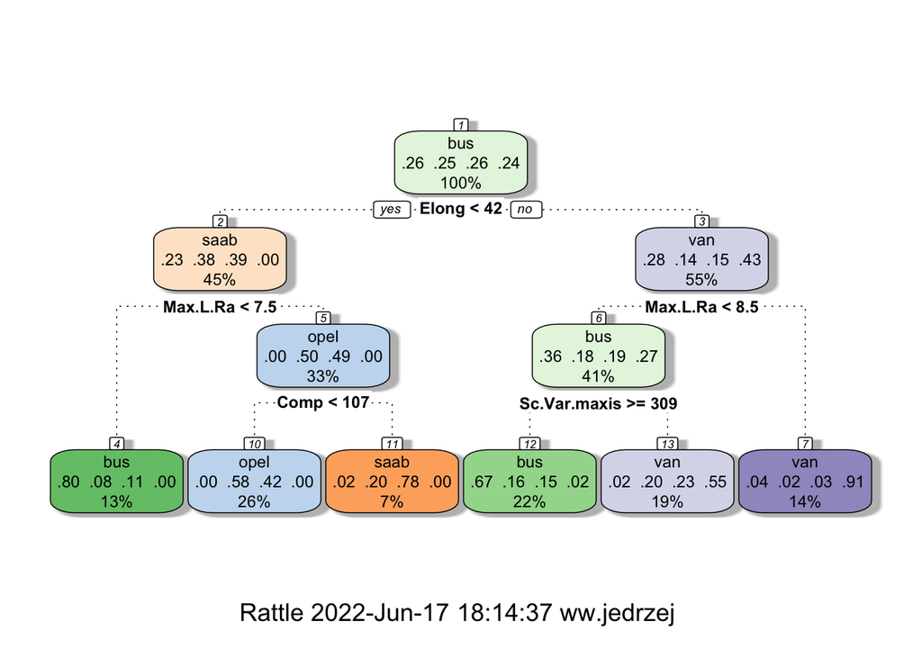

```r
fancyRpartPlot(model.tree$finalModel)
```

5. **Load the [dataset](http://www-stat.stanford.edu/~tibs/ElemStatLearn/datasets/SAheart.data). The dataset is about heart disease in South Africa. Determine the resubstitution error and LOO CV for the LDA method.**

Proposed answer:

```r
library(caret)

data <- read.table('http://www-stat.stanford.edu/~tibs/ElemStatLearn/datasets/SAheart.data',
                       header = TRUE,
                       row.names = 1,
                       sep = ',')

ctrl.loo = trainControl(method = "LOOCV")

model_lda = train(famhist ~ .,
                  data = data,
                  method = 'lda',
                  trControl = ctrl.loo)

model_lda
```

```
## Linear Discriminant Analysis
##
## 462 samples
##   9 predictor
##   2 classes: 'Absent', 'Present'
##
## No pre-processing
## Resampling: Leave-One-Out Cross-Validation
## Summary of sample sizes: 461, 461, 461, 461, 461, 461, ...
## Resampling results:
##
##   Accuracy   Kappa
##   0.6385281  0.2357207
```

```r
1 - as.numeric(model_lda$results[2]) # LOOCV
```

```
## [1] 0.3614719
```

```r
predicted_labels = predict(model_lda)
true_labels = data$famhist
mean(predicted_labels != true_labels) # Resubstitution Error
```

```
## [1] 0.3333333
```